# Act Report

## Storing, analyzing and visualizing wrangled data

The final section of the project was dedicated to **Storing, analyzing and visualizing wrangled data**.

We started off this section by storing the cleaned data into `twitter_archive_master.csv` and `image_predictions_master.csv` using the `pandas.DataFrame.to_csv` function. Index was set to `False` so we don't read the indices into the dataframes twice.

After familiarizing with the datasets in the previous wrangling steps, we were able to raise a few questions, for instance, we found out the **[this lovely Doggo](https://twitter.com/dog_rates/status/744234799360020481) scored 130 in the WeRateDogs rate scale, was favorited 157246 times and retweeted 78313 times**. By the time of our analysis, this tweet was the most retweeted and favorited from the entire tweet archive.

We also found that disregarding posts which a dog stage was not mentioned, **pupper is the dog stage that got the majority of ratings (222), followed by Doggo (84), Puppo (23) and lastly Floofer (9)**. The last two stages received way fewer ratings when compared to the first two. **Puppo and Floofer leads the ranking, with an average rating of 120 and approximately 119 respectively**. This may be due to the low number of ratings each received. Below a brief explanation on the various stages:

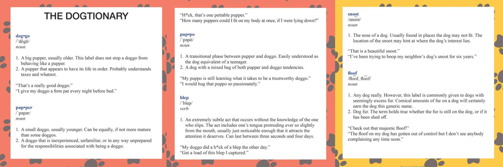

We were also interested to know which are the top 5 breeds with the highest ratings. We combined the data from `image_predictions` table with the `dogs_ratings` table and filtered only images of dogs with the highest prediction confidence.

We found that the Clumber Spaniel is leading by far the ranking of breeds with high ratings. Tweets of Clumber Spaniels scored on average 270, more than the double registered by the following four breeds Pomeranian (129), Saluki (127), Tibetan Mastiff (123), and Border Terrier (121).

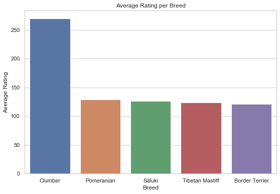

It turns out that the highest rating for this breed comes from [Sophie](https://twitter.com/dog_rates/status/778027034220126208). Isn't she lovely?

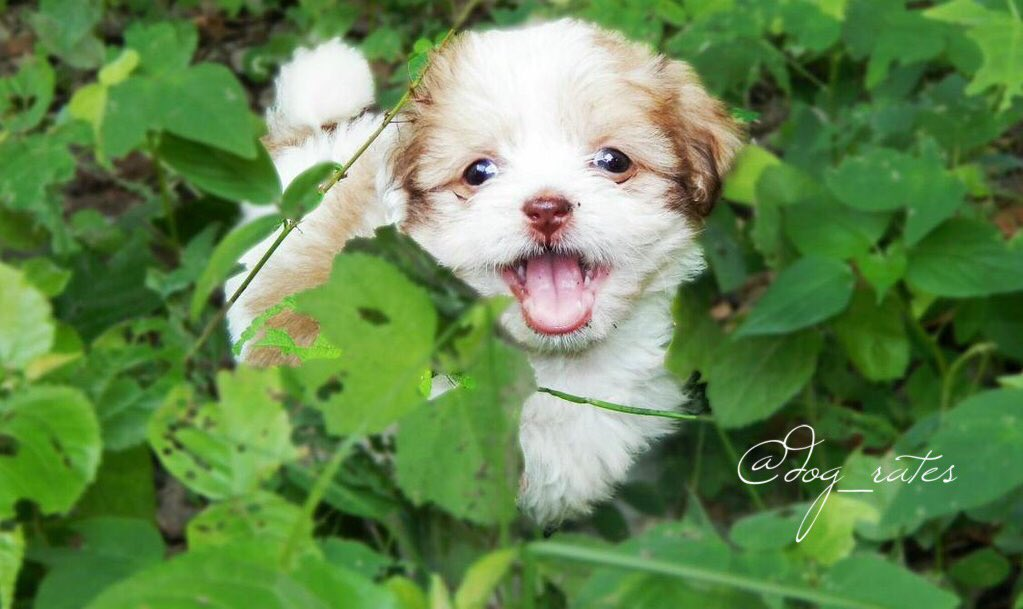